# Домашнее задание 4.

June 7, 2018

В четвёртой домашке будем искать главные компоненты в наборе данных об ирисах!

- **Упражнение 0.**

Подключите пакеты `tidyverse`, `skimr`, `rio`, `factoextra`, `corrplot`. И постарайтесь вспомнить, для чего нужен каждый из них :)

```r
library(tidyverse) # обработка данных, графики...
library(skimr) # описательные статистики
library(rio) # импорт фантастического количества форматов данных
library(factoextra) # визуализации kmeans, pca
```

```r
library(corrplot) # визуализация корреляций
```

Для упражнений мы будем использовать встроенный набор данных об ирисах. Узнать подробности можно в справке командой `?iris`.

- **Упраженение 1.**

Сначала поймём, с чем мы будем иметь дело :)

- Посмотрите на описательные статистики набора данных `iris`.
  - Сколько в них наблюдений? Сколько переменных?
  - Есть ли пропуски?
- Нарисуйте диаграмму рассеяния для длины лепестка `Petal.Length` и ширины лепестка `Petal.Width`. Раскрасьте точки и измените их форму в соответствии с видом ириса `Species`. Добавьте вертикальную линию на уровне средней длины лепестка и горизонтальную на уровне средней ширины лепестка. Не забудьте добавить название и подписи к осям!

```r
skim(iris)
```

```
## Skim summary statistics
##  n obs: 150
##  n variables: 5
```

```
##
## Variable type: factor
##  variable missing complete   n n_unique                       top_counts
##   Species       0      150 150        3 set: 50, ver: 50, vir: 50, NA: 0
##  ordered
##    FALSE
##
## Variable type: numeric
##      variable missing complete   n mean   sd  p0 p25  p50 p75 p100
##  Petal.Length       0      150 150 3.76 1.77 1   1.6 4.35 5.1  6.9
##   Petal.Width       0      150 150 1.2  0.76 0.1 0.3 1.3  1.8  2.5
##  Sepal.Length       0      150 150 5.84 0.83 4.3 5.1 5.8  6.4  7.9
##   Sepal.Width       0      150 150 3.06 0.44 2   2.8 3    3.3  4.4
##      hist
##  ▇▁▁▂▅▅▃▁
##  ▇▁▁▅▃▃▂▂
##  ▂▇▅▇▆▅▂▂
##  ▁▂▅▇▃▂▁▁
```

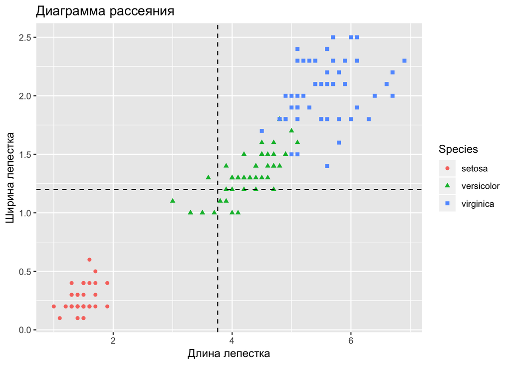

```r
ggplot(data = iris) +
  geom_point(aes(x = Petal.Length, y = Petal.Width, col = Species, shape = Species)) +
  geom_vline(aes(xintercept = mean(Petal.Length)), linetype = 'dashed') +
  geom_hline(aes(yintercept = mean(Petal.Width)), linetype = 'dashed') +
  labs(x = 'Длина лепестка', y = 'Ширина лепестка', title = 'Диаграмма рассеяния')
```

- Каковы средняя длина и ширина лепестка?
- За что отвечает аргумент `linetype`?
- **Упражнение 2.**
- Постройте гистограммы длины чашелистника для каждого вида ириса отдельно.
- А затем нарисуйте скрипичные графики для ширины чашелистника.

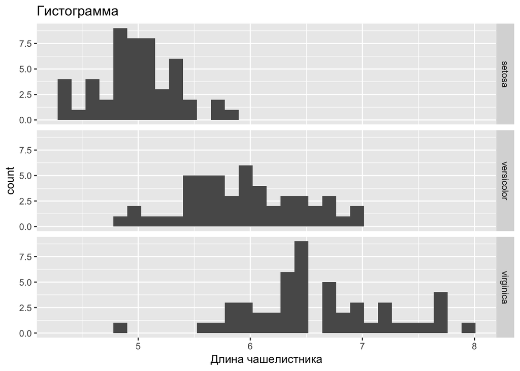

```r
ggplot(data = iris) +
  geom_histogram(aes(x = Sepal.Length)) +
  facet_grid(Species ~ .) +
  labs(x = 'Длина чашелистника', title = 'Гистограмма')
```

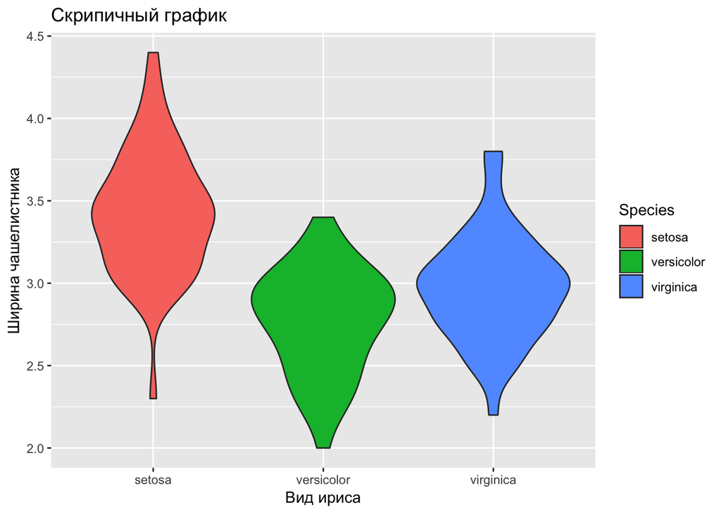

```r
ggplot(data = iris) +
  geom_violin(aes(x = Species, y = Sepal.Width, fill = Species)) +
  labs(x = 'Вид ириса', y = 'Ширина чашелистника', title = 'Скрипичный график')
```

- Сильно ли отличается распределение длины чашелистников по видам?
- У какого вида ириса в среднем самая большая ширина чашелистника?
- **Упражнение 3.**

Примените метод главных компонент к набору данных об ирисах, а затем визуализируйте результат в осях первых двух главных компонент. Помните, что эти данные не отмасштабированы, а значит, функции `prcomp()` нужно передать важный аргумент! Подсказка появляется при нажатии кнопки `tab` внутри скобок :)

```r
iris_pca <- prcomp(iris[-5], scale. = TRUE)
iris_pca
```

```
## Standard deviations (1, .., p=4):
## [1] 1.7083611 0.9560494 0.3830886 0.1439265
##
## Rotation (n x k) = (4 x 4):
##                     PC1         PC2        PC3        PC4
## Sepal.Length  0.5210659 -0.37741762  0.7195664  0.2612863
## Sepal.Width  -0.2693474 -0.92329566 -0.2443818 -0.1235096
## Petal.Length  0.5804131 -0.02449161 -0.1421264 -0.8014492
## Petal.Width   0.5648565 -0.06694199 -0.6342727  0.5235971
```

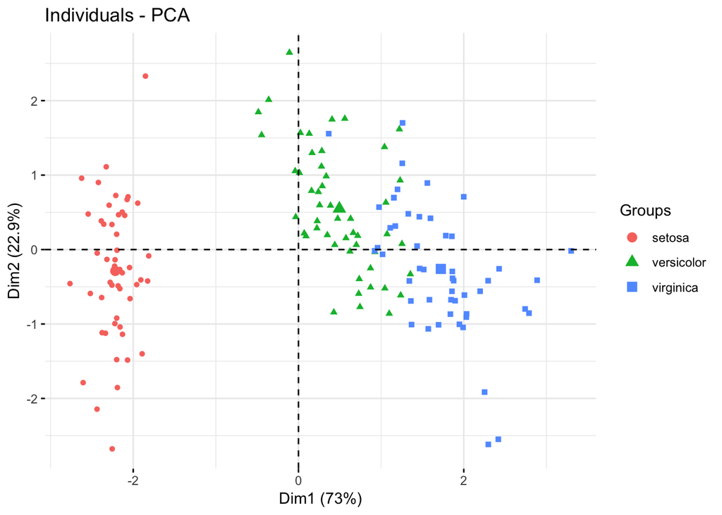

```r
fviz_pca_ind(iris_pca, label = 'none', habillage = iris$Species)
```

- Какую долю разброса данных объясняют первые две главные компоненты?
- Что изменится, если в функции `fviz_pca_ind()` не указывать аргументы `label` и `habillage`?
- **Упражнение 4.**

Нарисуйте проекции исходных переменных в осях первых двух главных компонент. Функции `fviz_pca_biplot` передайте аргумент, который делает подписи аккуратными.

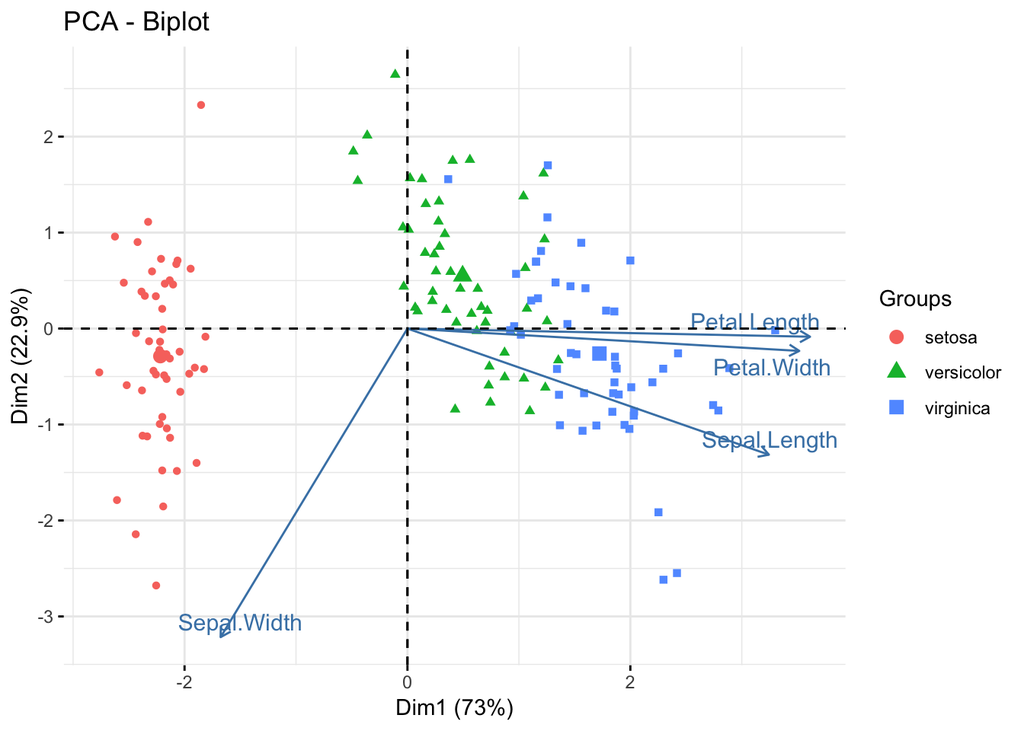

```r
fviz_pca_biplot(iris_pca, geom.ind = 'point', habillage = iris$Species, repel = TRUE)
```

- Какая исходная переменная входит во вторую главную компоненту с большим весом?
- За что отвечает аргумент `geom.ind = 'point'`? Какие ещё возможны опции?
- **Упражнение 5.**

Визуализируйте процент разброса, который объясняет каждая главная компонента и добавьте эти значения на график.

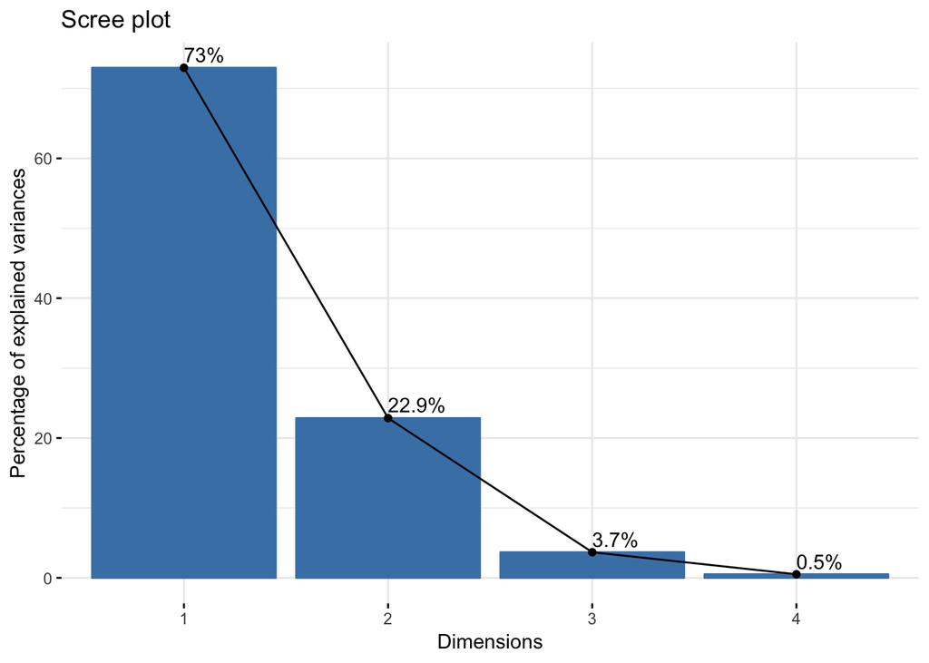

```r
fviz_eig(iris_pca, addlabels = TRUE)
```

- Достаточно ли взять первую главную компоненту, чтобы объяснить 70% разброса даныых?
- **Упражнение 6.**

Визуализируйте вклад каждой переменной во вторую главную компоненту.

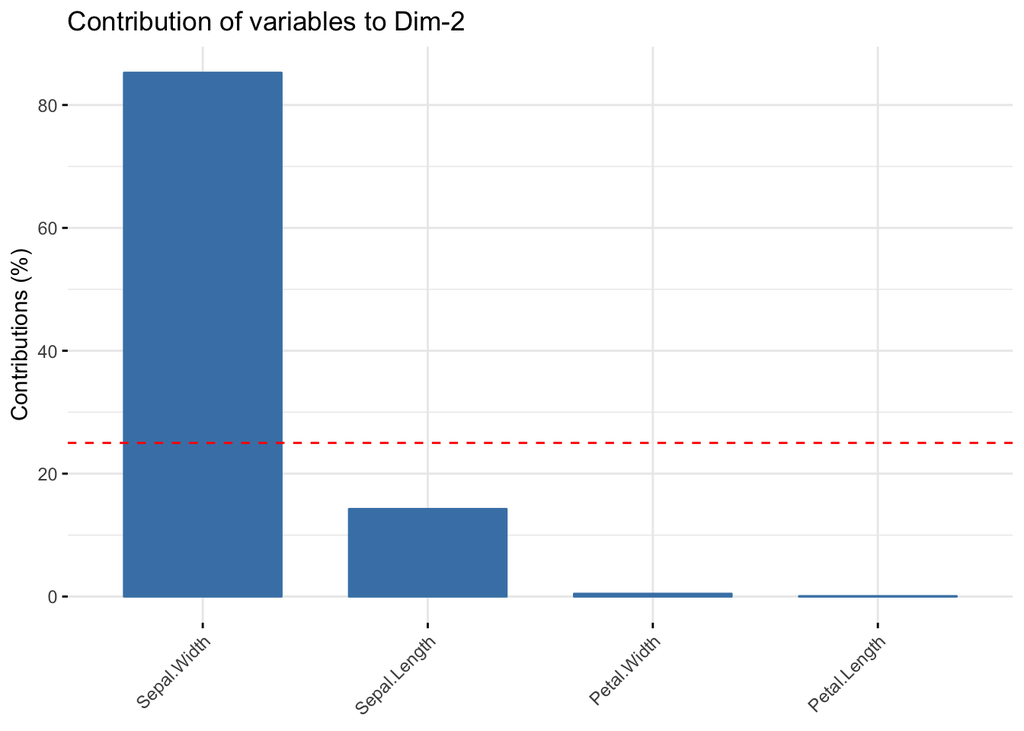

```r
fviz_contrib(iris_pca, choice = 'var', axes = 2)
```

- Вклад каких переменных во вторую главную компоненту можно считать значительным?
- **Упражнение 7.**

Домашка выполнена! Ура :) Теперь её можно показывать всем! Загрузите файл с домашним заданием `hw_040.Rmd` в свой гитхаб-репозиторий.